# R para análisis de confiabilidad en industrias de alto riesgo

R-Ladies Medellin

2023-08-12

# 1. Fault Tree Analysis (FTA) en R

Para desarrollar árboles de falla en R, es necesario instalar el paquete **FaultTree**. Si usted no ha utilizado aún este paquete, por favor siga las instrucciones de instalación que se presentan a continuación.

### 1.1 Procedimiento de instalación

**Opción A:** En general, desde la última versión de R, como administrador, debería poder simplemente copiar y pegar en la consola el siguiente comando de instalación

```r
install.packages("FaultTree", repos="http://R-Forge.R-project.org")
```

**Opción B:** Si el comando anterior no funciona, entonces…

- Verifique la versión de R que esta utilizando,
- Ingrese a https://cran.r-project.org/bin/windows/Rtools/ y descargue la versión de R Tools compatible con su versión de R,
- Instale R Tools,
- Reinicie su dispositivo e ingrese a R,
- Finalmente instale el paquete ‘FaultTree’ como acostumbra instalar sus paquetes en R.

**Ahora el paquete FaultTree debería estar disponible**

```r
library(FaultTree)
```

### 1.2 Ejemplo básico de FTA

Diseñe el árbol de fallas para el sistema presentado a continuación.

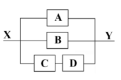

Asuma que la probabilidad de falla de los elemtos A, B y C es la misma y es equivalente a 0.1; mientras que dicha probabilidad para el elemento D es 0.2

Para diseñar el árbol de fallas utilizaremos la función **ftree.make**, informaremos el tipo de puerta lógica que condiciona nuestro evento de interés y definiremos un nombre para este.

```r
sistema <- ftree.make(type="and", name="No hay flujo en Y")
```

La puerta lógica corresponde a una relación **AND** porque la interrupción del flujo se da cuando: (i) A falla, (ii) B falla, y (iii) Falla C o D.

Para agregar la tercera causa (evento intermediario): ‘interrupción en el camino inferior’, utilizamos la función **addLogic**.

Perciba que la funcion necesita recibir la siguiente información: el nombre del arbol de fallas al cual sera adicionado el evento; la ubicacion de la puerta logica en la cual sera agregado el evento; la puerta lógica que condiciona el evento a ser agregado y el nombre del nuevo evento.

```r
sistema <- addLogic(sistema, at = 1, type = 'or', name = 'Interrupcion en el camino inferior')
```

La puerta lógica es una puerta **OR** porque basta con que fallé C o D para tener una interrupción en el flujo.

Ahora agregamos los eventos básicos relacionados con la falla de C y D, al evento intermediario.

Para agregar estas fallas (eventos básicos), utilizamos la función **addProbability**. Esta función recibe como inputs: el nombre del árbol de fallas al cual sera adicionado el evento básico; la ubicación de la puerta lógica en la cuál sera agregado el evento; el valor de probabilidad de falla del evento básico y el nombre definido para el evento.

```r
sistema <- addProbability(sistema, at = 2, prob = 0.1, name = "Falla C")
sistema <- addProbability(sistema, at = 2, prob = 0.2, name = "Falla D")
```

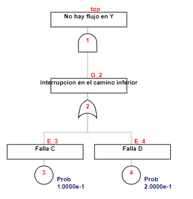

Finalmente, agregamos los eventos básicos relacionados con la falla de A y B.

```r
sistema <- addProbability(sistema, at = 1, prob = 0.1, name = "Falla A")
sistema <- addProbability(sistema, at = 1, prob = 0.1, name = "Falla B")
```

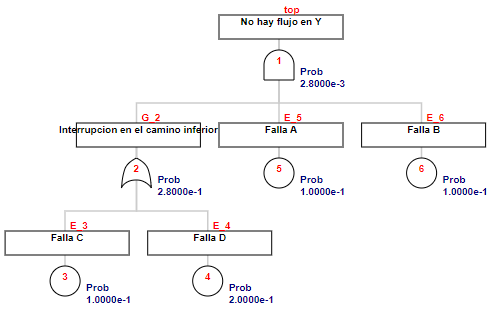

Para cuantificar el árbol, utilizamos la función **ftree.calc**. Es importante tornar verdadero el parámetro ‘use.bdd’ para obtener el valor exacto de la cuantificación.

En caso de desear cuantificar el árbol por el método del límite superior, usted deberá tornar falso este parámetro.

```r
sistema <- ftree.calc(sistema, use.bdd = TRUE)
```

Si desea visualizar el árbol, ejecute las siguientes líneas de código.

```r
ftree2html(sistema, write_file=TRUE)
browseURL("sistema.html")
```

# 2. Caso de estudio: Subsistema de control, unidad DP2

Actualmente las unidades posicionadas dinámicamente son responsables por la mayoría de operaciones offshore en la industria de petróleo y gas. Motivados por los análisis de confiabilidad en industrias de alto riesgo, desarrollaremos una estimación de la probabilidad de falla del subsistema de control de una unidad DP2. Nuestro estudio es soportado por la siguiente producción científica.

[figure not shown]

https://doi.org/10.1177/1748006X211051805

En el siguiente segmento de código, vamos a replicar el árbol de fallas correspondiente a la falla total del subsistema de control de la unidad DP2 (Figura 5).

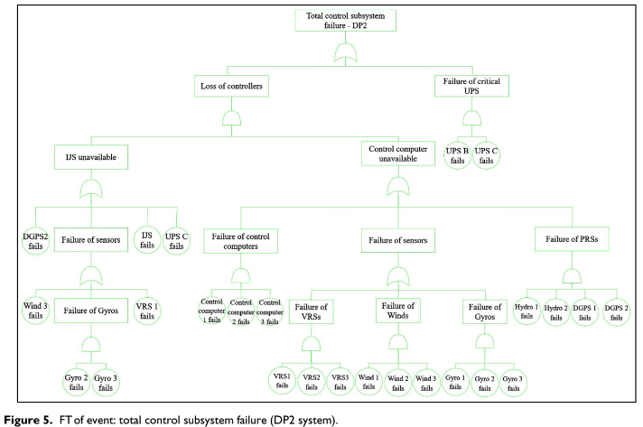

El primer paso en un análisis de confiabilidad es definir el *tiempo de misión* sobre el cual se desarrollará el estudio y la *probabilidad de falla* de los componentes del sistema.

En nuestro caso analizaremos el subsistema para un año operacional (8760 horas) y asumiremos que todos los componentes del subsistema se encuentran en *etapa de vida útil*.

```r
T_mission = 8760
wind      = pexp(T_mission, 0.0000515)
VRS       = pexp(T_mission, 0.0000113)
gyro      = pexp(T_mission, 0.0000333)
hydro     = pexp(T_mission, 0.0000285)
DGPS      = pexp(T_mission, 0.0000102)
UPS       = pexp(T_mission, 0.00000895)
IJS       = pexp(T_mission, 0.0000174)
computer  = pexp(T_mission, 0.0000174)
```

Una vez definimos el tiempo de misión del sistema en estudio y la probabilidad de falla de los componentes, iniciaremos la construcción de nuestro árbol de fallas.

```r
# Definir evento top
control <- ftree.make(type="or", name="Subsistema de control - DP2")
```

Nuestro evento de interés ocurre por dos causas principales: (1) la pérdida de los controladores, o (2) la falla de las UPS (Uninterruptible Power Supply) críticas.

```r
# Agregaremos dos eventos intermediarios a la puerta 1
control <- addLogic(control, at = 1, type = 'and', name = 'Perdida de controladores')
control <- addLogic(control, at = 1, type = 'and', name = 'Falla de UPS criticas')
```

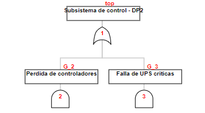

La pérdida de los controladores ocurre con la indisponibilidad de los computadores de control principales y el IJS (Independent Joystick System).

```r
# Agregaremos dos eventos intermediarios a la puerta 2
control <- addLogic(control, at = 2, type = 'or', name = 'IJS indisponible')
control <- addLogic(control, at = 2, type = 'or', name = 'Computadores indisponibles')
```

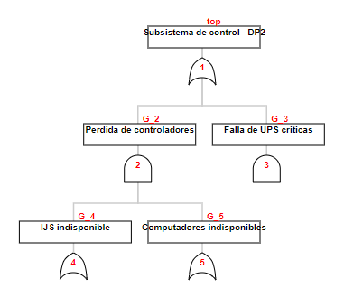

Mientras que las UPS críticas identificadas en esta unidad son la UPS B y la UPS C.

```r
# Agregaremos dos eventos basicos a la puerta 3
control <- addProbability(control, at = 3, prob = UPS, name = "Falla UPS B")
control <- addProbability(control, at = 3, prob = UPS, name = "Falla UPS C")
```

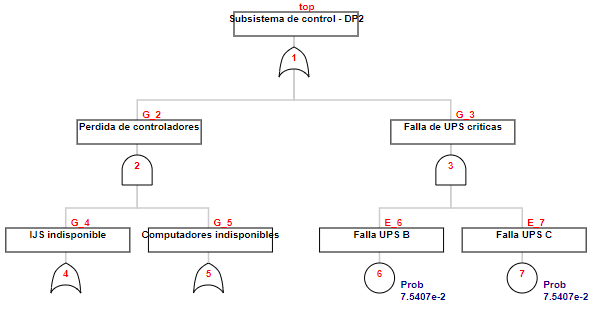

Ahora daremos contuinidad a los eventos intermediarios de la puerta 2

```r
# Definimos las causas relacionadas con la indisponibilidad del IJS
control <- addProbability(control, at = 4, prob = DGPS, name="Falla DGPS 2")
control <- addProbability(control, at = 4, prob = IJS, name="Falla IJS")
control <- addDuplicate(control, at = 4, dup_id = 7)
```

Algunos eventos básicos pueden contruibuir a dos eventos intermediarios. Por tanto es necesario informar al programa que existe un evento básico duplicado. Para esto utilizaremos la función **addDuplicate**. Esta función recibe como inputs: el nombre del árbol de fallas en el cual será duplicado el evento básico; la ubicación de la puerta lógica en la cual sera agregado el evento duplicado y el id del evento básico a duplicar.

Continuando con las causas relacionadas con la indisponibilidad del IJS, tenemos…

```r
control <- addLogic(control, at = 4, type = 'or', name = 'Fallan sensores del IJS')
control <- addProbability(control, at = 11, prob = wind, name = "Falla wind 3")
control <- addProbability(control, at = 11, prob = VRS, name = "Falla VRS 1")
control <- addLogic(control, at = 11, type = 'and', name = 'Fallan los Giroscopios (IJS)')
control <- addProbability(control, at = 14, prob = gyro, name = "Falla gyro 2")
control <- addProbability(control, at = 14, prob = gyro, name = "Falla gyro 3")
```

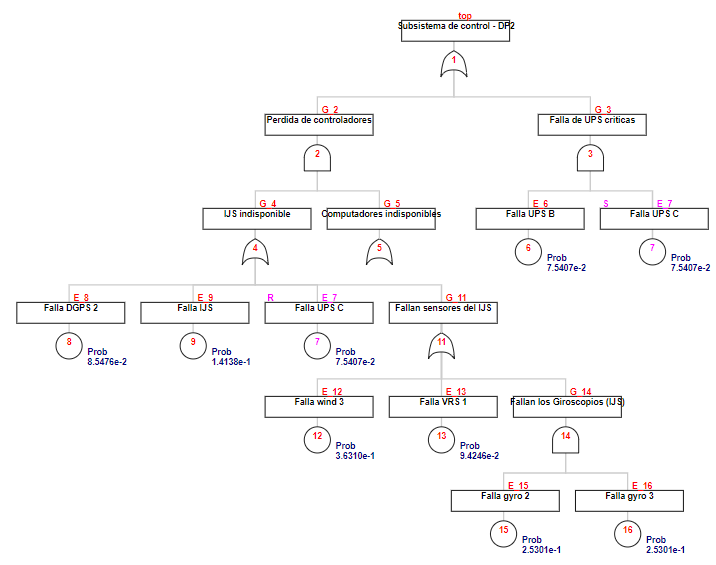

Finalmente agregaremos la información del último evento intermediario de la puerta 2

```r
# Definimos las causas relacionadas con la indisponibilidad de los computadores
control <- addLogic(control, at = 5, type = 'and', name = 'Falla de los computadores')
control <- addLogic(control, at = 5, type = 'or', name = 'Fallan sensores de computadores')
control <- addLogic(control, at = 5, type = 'and', name = 'Fallan PRSs de computadores')
```

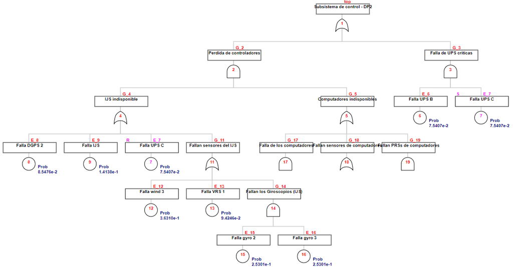

Agregamos los eventos básicos relacionados con los tres computadores de control principales

```r
# Falla de los computadores
control <- addProbability(control, at = 17, prob = computer, name = "Falla computador 1")
control <- addProbability(control, at = 17, prob = computer, name = "Falla computador 2")
control <- addProbability(control, at = 17, prob = computer, name = "Falla computador 3")
```

Agregamos los eventos relacionados con los sensores de los computadores

```r
# Fallan sensores de computadores
control <- addLogic(control, at = 18, type = 'and', name = 'Fallan los VRSs')
control <- addLogic(control, at = 18, type = 'and', name = 'Fallan los sensores de viento')
control <- addLogic(control, at = 18, type = 'and', name = 'Fallan los Giroscopios (computadores)')
```

Eventos básicos relacionados con los sensores de referencia vertical

```r
# Fallan los VRSs
control <- addDuplicate(control, at = 23, dup_id = 13)
control <- addProbability(control, at = 23, prob = VRS, name = "Falla VRS 2")
control <- addProbability(control, at = 23, prob = VRS, name = "Falla VRS 3")
```

Eventos básicos relacionados con los sensores de viento

```r
# Fallan los sensores de viento
control <- addProbability(control, at = 24, prob = wind, name="Falla wind 1")
control <- addProbability(control, at = 24, prob = wind, name="Falla wind 2")
control <- addDuplicate(control, at = 24, dup_id = 12)
```

Eventos básicos relacionados con los giróscopios

```r
# Fallan los Giroscopios (computadores)
control <- addProbability(control, at = 25, prob = gyro, name="Falla gyro 1")
control <- addDuplicate(control, at = 25, dup_id = 15)
control <- addDuplicate(control, at = 25, dup_id = 16)
```

Agregamos los eventos básicos relacionados con los sistemas de referencia de posición

```r
# Fallan PRSs de computadores
control <- addProbability(control, at = 19, prob = hydro, name="Falla hydro 1")
control <- addProbability(control, at = 19, prob = hydro, name="Falla hydro 2")
control <- addProbability(control, at = 19, prob = DGPS, name="Falla DGPS 1")
control <- addDuplicate(control, at = 19, dup_id = 8)
```

Cuantificacion del árbol de fallas ‘Subsistema de control, unidad DP2’

```r
# Estimation of top event
control <- ftree.calc(control, use.bdd = TRUE)

ftree2html(control, write_file=TRUE)
browseURL("control.html")
```